# Git Basics

## Git for collaboration

- Backup your code
- Synchronize between laptop and HPC
- Git is an industry standard
- Collaborate with others
- Share your code

[figure not shown]

## Setting up GitHub or GitLab

There are two protocols to use with git: https and ssh

```
# HTTPS
git clone \
  https://github.com/icbi-lab/current-topics-bioinformatics-lecture.git

# ssh
git clone \
  git@github.com:icbi-lab/current-topics-bioinformatics-lecture.git
```

We recommend using ssh as it allows to set-up passwordless authentication.

## Passwordless authentication

Generate a ssh key-pair. It consists of a public and a private key.

- Keep the private key secret (i.e. in your home directory only)
- you can share the public key with anyone (e.g. with GitHub)
- Everyone who possesses the public key can check if a message was signed using corresponding private key, thereby verifying your identity.

```bash
# Generate a key-pair. Hit enter 3x to use
# default settings and no additional password.
ssh-keygen

# display the public key
cat ~/.ssh/id_rsa.pub
```

## Add public key to GitHub

[figure not shown]

## Using remotes

- different users can point to the same remote
- the same repo can point to multiple remotes (e.g. GitHub and GitLab)

List remotes

```bash
git remote -v
```

Add a remote

```bash
# per convention, the default remote is called "origin"
git remote add origin \
  git@github.com:icbi-lab/current-topics-bioinformatics-lecture.git

# but you can have other remotes as well
git remote add my-fork \
  git@github.com:grst/current-topics-bioinformatics-lecture.git
```

## Pull/Push

Push to a remote

```bash
# git push <remote> <branch>
git push origin master
git push my-fork master
```

Pull from a remote

```bash
git pull origin master
```

Set a default remote for current branch

```bash
git push -u origin master
# now just use git pull/push without branch and remote
git push
```

## Tags and Releases

- A tag marks a certain commit in a repository
- Use this for creating versions of your tool or your analysis
- Take a look at [semantic versioning](https://semver.org/lang/de/) for choosing version numbers.

```bash
# create a tag
git tag v0.1.0

# sync it with a remote
git push --tags
```

## Releases

- Releases are a feature of GitHub/GitLab and work on top of tags
- They
  - make a tag more visible
  - allow you to store additional information

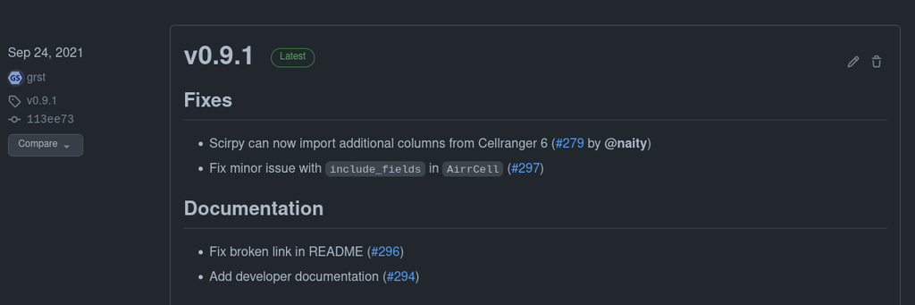

## Issues and Pull-requests

The typical open-source collaboration workflow:

- open an issue (bug report or feature request)
- Someone creates a pull-request
- The maintainer reviews and merges the pull-request
- The issue is closed

Example from `nf-core/modules`:

- Issue [#854](https://github.com/nf-core/modules/issues/854)
- Pull-request [#975](https://github.com/nf-core/modules/pull/975)

Example from `icbi-lab/scirpy`:

- Issue [#279](https://github.com/icbi-lab/scirpy/issues/279)
- Pull-request [#290](https://github.com/icbi-lab/scirpy/pull/290)

## Why do code reviews?

- Find mistakes and ensure code quality
- Discuss different implementations
- Distribute knowledge of the code base ([bus factor](https://en.wikipedia.org/wiki/Bus_factor))
- **learn from each other**
  - As a novice reviewer, ask questions (-> [blog post](https://medium.com/pinterest-engineering/how-to-review-code-as-a-junior-developer-10ffb7846958))

## Use issues and project-boards to organize your project

[figure not shown]

https://github.com/icbi-lab/scirpy/projects/1

## Continuous integration (CI)

- run a script at every `git push`
- used for
  - automated tests
  - deploying releases

The course website uses CI to automatically build slides from Rmarkdown documents. See

- [`.github/workflows/render_yml.yml`](https://github.com/icbi-lab/current-topics-bioinformatics-lecture/blob/master/.github/workflows/render_rmd.yml)
- [`render_all.sh`](https://github.com/icbi-lab/current-topics-bioinformatics-lecture/blob/master/render_all.sh)

## Further reading

- [Learn git in Y minutes](https://learnxinyminutes.com/docs/git/)
- [First time contributor’s guide by GitHub](https://github.com/firstcontributions/first-contributions)
- [Hallmarks of Good Scientific Software](https://grst.github.io/bioinformatics/2020/07/16/hallmarks-scientific-software.html)
- [How to Make Your Code Reviewer Fall in Love with You](https://mtlynch.io/code-review-love/)
- [How to Review Code as a Junior Developer](https://medium.com/pinterest-engineering/how-to-review-code-as-a-junior-developer-10ffb7846958)